# Personal Loan Campaign

AllLife Bank is a US bank that has a growing customer base. The majority of these customers are liability customers (depositors) with varying sizes of deposits. The number of customers who are also borrowers (asset customers) is quite small, and the bank is interested in expanding this base rapidly to bring in more loan business and in the process, earn more through the interest on loans. In particular, the management wants to explore ways of converting its liability customers to personal loan customers (while retaining them as depositors).

A campaign that the bank ran last year for liability customers showed a healthy conversion rate of over 9% success. This has encouraged the retail marketing department to devise campaigns with better target marketing to increase the success ratio.

You as a Data scientist at AllLife bank have to build a model that will help the marketing department to identify the potential customers who have a higher probability of purchasing the loan.

## Objective

- To predict whether a liability customer will buy a personal loan or not.
- Which variables are most significant.
- Which segment of customers should be targeted more.

## Data Dictionary

- ID: Customer ID
- Age: Customer’s age in completed years
- Experience: #years of professional experience
- Income: Annual income of the customer (in thousand dollars)
- ZIP Code: Home Address ZIP code.
- Family: the Family size of the customer
- CCAvg: Average spending on credit cards per month (in thousand dollars)
- Education: Education Level. 1: Undergrad; 2: Graduate;3: Advanced/Professional
- Mortgage: Value of house mortgage if any. (in thousand dollars)
- Personal_Loan: Did this customer accept the personal loan offered in the last campaign?
- Securities_Account: Does the customer have securities account with the bank?
- CD_Account: Does the customer have a certificate of deposit (CD) account with the bank?
- Online: Do customers use internet banking facilities?
- CreditCard: Does the customer use a credit card issued by any other Bank (excluding All life Bank)?

### Import the necessary packages

```python
# Library to suppress warnings or deprecation notes
import warnings

warnings.filterwarnings("ignore")

# Libraries to help with reading and manipulating data

import pandas as pd
import numpy as np

# Library to split data
from sklearn.model_selection import train_test_split

# libaries to help with data visualization
import matplotlib.pyplot as plt
import seaborn as sns

# Removes the limit for the number of displayed columns
pd.set_option("display.max_columns", None)
# Sets the limit for the number of displayed rows
pd.set_option("display.max_rows", 200)

# Libraries to build decision tree classifier
from sklearn.tree import DecisionTreeClassifier
from sklearn.preprocessing import PowerTransformer
from sklearn.linear_model import LogisticRegression
from sklearn import tree

# To tune different models
from sklearn.model_selection import GridSearchCV

# To get diferent metric scores
from sklearn.metrics import (
    f1_score,
    accuracy_score,
    recall_score,
    precision_score,
    confusion_matrix,
    plot_confusion_matrix,
    make_scorer,
)
```

### Read the dataset

```python
data = pd.read_csv("Loan_Modelling.csv")
```

```python
# copying data to another varaible to avoid any changes to original data
loan = data.copy()
```

## Understanding the structure of the data

### View the first and last 5 rows of the dataset.

```python
loan.head()
```

|  | ID | Age | Experience | Income | ZIPCode | Family | CCAvg | Education | Mortgage | Personal_Loan | Securities_Account | CD_Account | Online | CreditCard |
| --- | --- | --- | --- | --- | --- | --- | --- | --- | --- | --- | --- | --- | --- | --- |
| 0 | 1 | 25 | 1 | 49 | 91107 | 4 | 1.6 | 1 | 0 | 0 | 1 | 0 | 0 | 0 |
| 1 | 2 | 45 | 19 | 34 | 90089 | 3 | 1.5 | 1 | 0 | 0 | 1 | 0 | 0 | 0 |
| 2 | 3 | 39 | 15 | 11 | 94720 | 1 | 1.0 | 1 | 0 | 0 | 0 | 0 | 0 | 0 |
| 3 | 4 | 35 | 9 | 100 | 94112 | 1 | 2.7 | 2 | 0 | 0 | 0 | 0 | 0 | 0 |
| 4 | 5 | 35 | 8 | 45 | 91330 | 4 | 1.0 | 2 | 0 | 0 | 0 | 0 | 0 | 1 |

```python
loan.tail()
```

|  | ID | Age | Experience | Income | ZIPCode | Family | CCAvg | Education | Mortgage | Personal_Loan | Securities_Account | CD_Account | Online | CreditCard |
| --- | --- | --- | --- | --- | --- | --- | --- | --- | --- | --- | --- | --- | --- | --- |
| 4995 | 4996 | 29 | 3 | 40 | 92697 | 1 | 1.9 | 3 | 0 | 0 | 0 | 0 | 1 | 0 |
| 4996 | 4997 | 30 | 4 | 15 | 92037 | 4 | 0.4 | 1 | 85 | 0 | 0 | 0 | 1 | 0 |
| 4997 | 4998 | 63 | 39 | 24 | 93023 | 2 | 0.3 | 3 | 0 | 0 | 0 | 0 | 0 | 0 |
| 4998 | 4999 | 65 | 40 | 49 | 90034 | 3 | 0.5 | 2 | 0 | 0 | 0 | 0 | 1 | 0 |
| 4999 | 5000 | 28 | 4 | 83 | 92612 | 3 | 0.8 | 1 | 0 | 0 | 0 | 0 | 1 | 1 |

### Understand the shape of the dataset.

```python
loan.shape
```

```
(5000, 14)
```

**Observation:** The dataset has 5000 rows and 14 columns of data

### Check the data types of the columns for the dataset.

```python
loan.info()
```

```
<class 'pandas.core.frame.DataFrame'>
RangeIndex: 5000 entries, 0 to 4999
Data columns (total 14 columns):
 #   Column              Non-Null Count  Dtype
---  ------              --------------  -----
 0   ID                  5000 non-null   int64
 1   Age                 5000 non-null   int64
 2   Experience          5000 non-null   int64
 3   Income              5000 non-null   int64
 4   ZIPCode             5000 non-null   int64
 5   Family              5000 non-null   int64
 6   CCAvg               5000 non-null   float64
 7   Education           5000 non-null   int64
 8   Mortgage            5000 non-null   int64
 9   Personal_Loan       5000 non-null   int64
 10  Securities_Account  5000 non-null   int64
 11  CD_Account          5000 non-null   int64
 12  Online              5000 non-null   int64
 13  CreditCard          5000 non-null   int64
dtypes: float64(1), int64(13)
memory usage: 547.0 KB
```

**Observation:** All the variables are int data type except CCAvg which is float

### Summary of the dataset.

```python
loan.describe(include="all")
```

|  | ID | Age | Experience | Income | ZIPCode | Family | CCAvg | Education | Mortgage | Personal_Loan | Securities_Account | CD_Account | Online | CreditCard |
| --- | --- | --- | --- | --- | --- | --- | --- | --- | --- | --- | --- | --- | --- | --- |
| count | 5000.000000 | 5000.000000 | 5000.000000 | 5000.000000 | 5000.000000 | 5000.000000 | 5000.000000 | 5000.000000 | 5000.000000 | 5000.000000 | 5000.000000 | 5000.00000 | 5000.000000 | 5000.000000 |
| mean | 2500.500000 | 45.338400 | 20.104600 | 73.774200 | 93169.257000 | 2.396400 | 1.937938 | 1.881000 | 56.498800 | 0.096000 | 0.104400 | 0.06040 | 0.596800 | 0.294000 |
| std | 1443.520003 | 11.463166 | 11.467954 | 46.033729 | 1759.455086 | 1.147663 | 1.747659 | 0.839869 | 101.713802 | 0.294621 | 0.305809 | 0.23825 | 0.490589 | 0.455637 |
| min | 1.000000 | 23.000000 | -3.000000 | 8.000000 | 90005.000000 | 1.000000 | 0.000000 | 1.000000 | 0.000000 | 0.000000 | 0.000000 | 0.00000 | 0.000000 | 0.000000 |
| 25% | 1250.750000 | 35.000000 | 10.000000 | 39.000000 | 91911.000000 | 1.000000 | 0.700000 | 1.000000 | 0.000000 | 0.000000 | 0.000000 | 0.00000 | 0.000000 | 0.000000 |
| 50% | 2500.500000 | 45.000000 | 20.000000 | 64.000000 | 93437.000000 | 2.000000 | 1.500000 | 2.000000 | 0.000000 | 0.000000 | 0.000000 | 0.00000 | 1.000000 | 0.000000 |
| 75% | 3750.250000 | 55.000000 | 30.000000 | 98.000000 | 94608.000000 | 3.000000 | 2.500000 | 3.000000 | 101.000000 | 0.000000 | 0.000000 | 0.00000 | 1.000000 | 1.000000 |
| max | 5000.000000 | 67.000000 | 43.000000 | 224.000000 | 96651.000000 | 4.000000 | 10.000000 | 3.000000 | 635.000000 | 1.000000 | 1.000000 | 1.00000 | 1.000000 | 1.000000 |

```python
# To check number of unique elements in each columns
loan.nunique()
```

```
ID                    5000
Age                     45
Experience              47
Income                 162
ZIPCode                467
Family                   4
CCAvg                  108
Education                3
Mortgage               347
Personal_Loan            2
Securities_Account       2
CD_Account               2
Online                   2
CreditCard               2
dtype: int64
```

**Observation:**

- Since all the values in ID column are unique we can drop it
- Zip Code has 467 distinct value.

Since these fields will not affect our predictions we can drop it

### Data Preprocessing

```python
loan.drop(["ID"], axis=1, inplace=True)
```

```python
loan.drop(["ZIPCode"], axis=1, inplace=True)
```

### Check for missing values

```python
loan.isnull().sum()
```

```
Age                   0
Experience            0
Income                0
Family                0
CCAvg                 0
Education             0
Mortgage              0
Personal_Loan         0
Securities_Account    0
CD_Account            0
Online                0
CreditCard            0
dtype: int64
```

**Observation:** There are no missing vaues in the dataset

## Data Visualization - Univariate analysis

- Univariate analysis refer to the analysis of a single variable. The main purpose of univariate analysis is to summarize and find patterns in the data. The key point is that there is only one variable involved in the analysis.

  Let us take the loan dataset and work on that for the univariate analysis.

```python
# function to create labeled barplots


def labeled_barplot(data, feature, perc=False, n=None):
    """
    Barplot with percentage at the top

    data: dataframe
    feature: dataframe column
    perc: whether to display percentages instead of count (default is False)
    n: displays the top n category levels (default is None, i.e., display all levels)
    """

    total = len(data[feature])  # length of the column
    count = data[feature].nunique()
    if n is None:
        plt.figure(figsize=(count + 2, 6))
    else:
        plt.figure(figsize=(n + 2, 6))

    plt.xticks(rotation=90, fontsize=15)
    ax = sns.countplot(
        data=data,
        x=feature,
        palette="Paired",
        order=data[feature].value_counts().index[:n].sort_values(),
    )

    for p in ax.patches:
        if perc == True:
            label = "{:.1f}%".format(
                100 * p.get_height() / total
            )  # percentage of each class of the category
        else:
            label = p.get_height()  # count of each level of the category

        x = p.get_x() + p.get_width() / 2  # width of the plot
        y = p.get_height()  # height of the plot

        ax.annotate(
            label,
            (x, y),
            ha="center",
            va="center",
            size=12,
            xytext=(0, 5),
            textcoords="offset points",
        )  # annotate the percentage

    plt.show()  # show the plot
```

#### Observation on Age

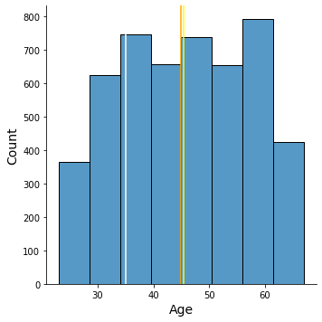

```python
# plots a histogram plt using the seaborn package for Age column.
# Using displot since distplot going to be decommissioned in the future

sns.displot(loan,
            x = "Age",
            bins=8,
            height=5)
plt.xlabel("Age", size=14)
plt.ylabel("Count", size=14)
plt.axvline(x=loan.Age.mean(),
            color='yellow')
plt.axvline(x=loan.Age.median(),
            color='orange')
plt.axvline(x=loan.Age.mode()[0],
            color='white')
```

#### Observation on Experience

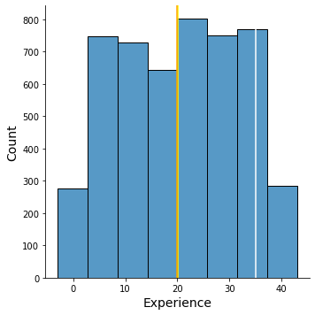

```python
# plots a histogram plt using the seaborn package for Experience column.
# Using displot since distplot going to be decommissioned in the future

sns.displot(loan,
            x = "Experience",
            bins=8,
            height=5)
plt.xlabel("Experience", size=14)
plt.ylabel("Count", size=14)
plt.axvline(x=loan.Experience.mean(),
            color='yellow')
plt.axvline(x=loan.Experience.median(),
            color='orange')
plt.axvline(x=loan.Age.mode()[0],
            color='white')
```

**Observation:** There are some negative experience found in the Experience column

```python
#To check the count of negative values
loan[loan['Experience'] < 0]['Experience'].value_counts()
```

```
-1    33
-2    15
-3     4
Name: Experience, dtype: int64
```

```python
# Dropping Experience column since its highly correlated with Age column

loan.drop(["Experience"], axis=1, inplace=True)
```

#### Observation on Income

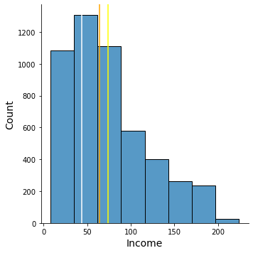

```python
# plots a histogram plt using the seaborn package for Income column.
# Using displot since distplot going to be decommissioned in the future

sns.displot(loan,
            x = "Income",
            bins=8,
            height=5)
plt.xlabel("Income", size=14)
plt.ylabel("Count", size=14)
plt.axvline(x=loan.Income.mean(),
            color='yellow')
plt.axvline(x=loan.Income.median(),
            color='orange')
plt.axvline(x=loan.Income.mode()[0],
            color='white')
```

#### Observations on Family

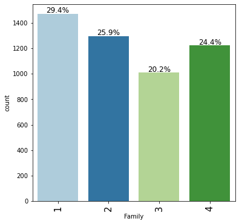

```python
labeled_barplot(loan, "Family", perc=True)
```

#### Observations on CCAvg

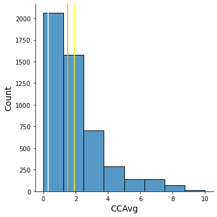

```python
# plots a histogram plt using the seaborn package for CCAVG column.
# Using displot since distplot going to be decommissioned in the future

sns.displot(loan,
            x = "CCAvg",
            bins=8,
            height=5)
plt.xlabel("CCAvg", size=14)
plt.ylabel("Count", size=14)
plt.axvline(x=loan.CCAvg.mean(),
            color='yellow')
plt.axvline(x=loan.CCAvg.median(),
            color='orange')
plt.axvline(x=loan.CCAvg.mode()[0],
            color='white')
```

#### Observations on Education

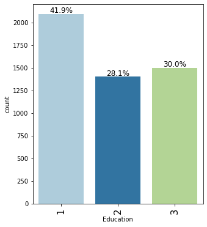

```python
labeled_barplot(loan, "Education", perc=True)
```

#### Observations on Mortgage

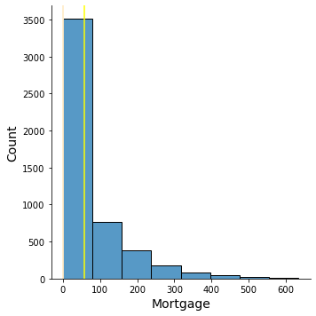

```python
# plots a histogram plt using the seaborn package for Mortgage column.
# Using displot since distplot going to be decommissioned in the future

sns.displot(loan,
            x = "Mortgage",
            bins=8,
            height=5)
plt.xlabel("Mortgage", size=14)
plt.ylabel("Count", size=14)
plt.axvline(x=loan.Mortgage.mean(),
            color='yellow')
plt.axvline(x=loan.Mortgage.median(),
            color='orange')
plt.axvline(x=loan.Mortgage.mode()[0],
            color='white')
```

#### Observations on CreditCard

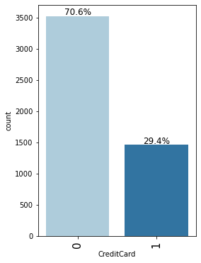

```python
labeled_barplot(loan, "CreditCard", perc=True)
```

#### Observations on Online

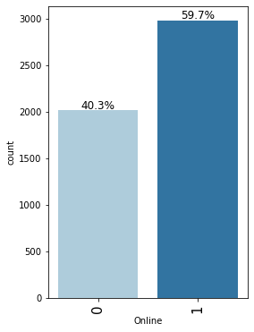

```python
labeled_barplot(loan, "Online", perc=True)
```

**Observations:** Income, CCAVg and Mortgage variables are right skewed so we have to take care of these

## Bivariate Analysis

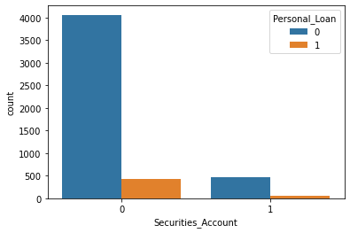

```python
sns.countplot(x="Securities_Account",hue="Personal_Loan",data=loan)
```

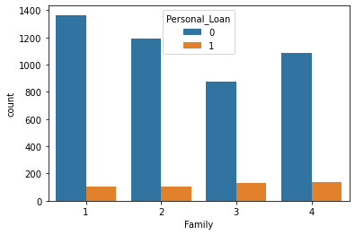

```python
sns.countplot(x='Family',hue='Personal_Loan',data=loan)
```

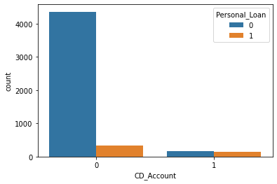

```python
sns.countplot(x='CD_Account',hue='Personal_Loan',data=loan)
```

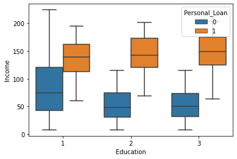

```python
sns.boxplot(x='Education',y='Income',hue='Personal_Loan',data=loan)
```

**Observations:**

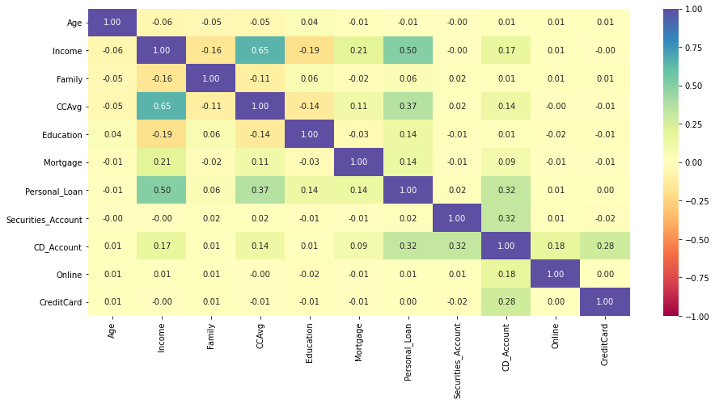

```python
# Heatmap

plt.figure(figsize=(15, 7))
sns.heatmap(
    loan.corr(), annot=True, vmin=-1, vmax=1, fmt=".2f", cmap="Spectral"
)
plt.show()
```

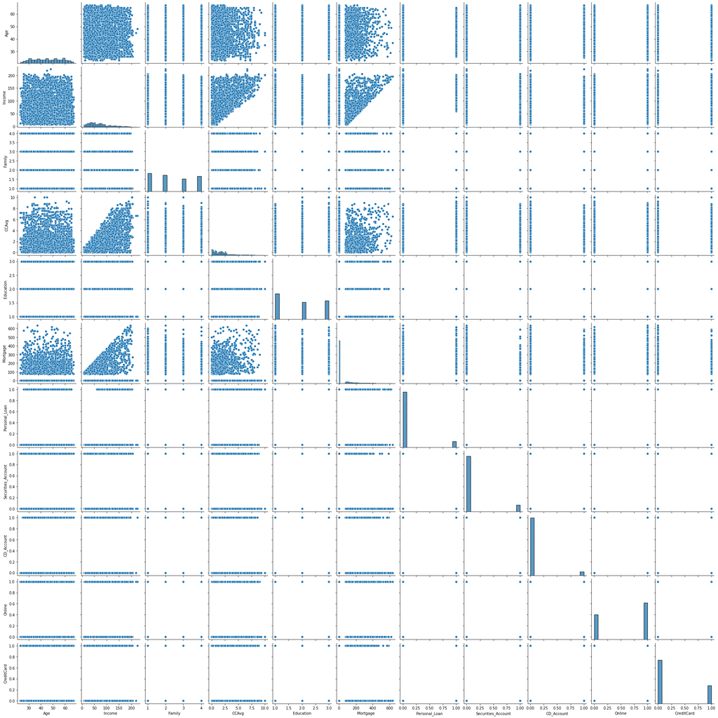

```python
# Pairplot

sns.pairplot(data=loan)
plt.show()
```

## Data Pre-processing

```python
X = loan.drop(["Personal_Loan"], axis=1)
y = loan["Personal_Loan"]
```

```python
# Applying the Yeo Johnson method of Transformation on the Income variable.
pt = PowerTransformer(method='yeo-johnson',standardize=False)
pt.fit(X['Income'].values.reshape(-1,1))
temp = pt.transform(X['Income'].values.reshape(-1,1))
X['Income'] = pd.Series(temp.flatten())
```

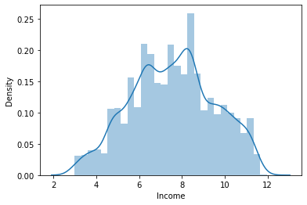

```python
# Distplot to show transformed Income variable
sns.distplot(X['Income'])
plt.show()
```

```python
# Applying the Yeo Johnson method of Transformation on the CCAvg variable.
pt = PowerTransformer(method='yeo-johnson',standardize=False)
pt.fit(X['CCAvg'].values.reshape(-1,1))
temp = pt.transform(X['CCAvg'].values.reshape(-1,1))
X['CCAvg'] = pd.Series(temp.flatten())
```

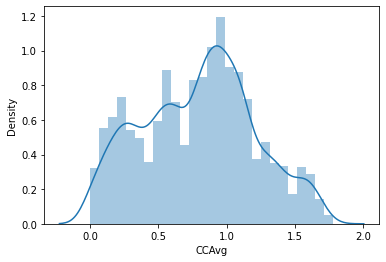

```python
# Distplot to show transformed CCAvg variable
sns.distplot(X['CCAvg'])
plt.show()
```

```python
# Binning on Mortgage variable.
X['Mortgage_val'] = pd.cut(X['Mortgage'],
                               bins=[0,100,200,300,400,500,600,700],
                               labels= [0,1,2,3,4,5,6],
                               include_lowest =True)
X.drop('Mortgage', axis = 1, inplace= True)
```

```python
# To display top 5 rows
X.head()
```

|  | Age | Experience | Income | Family | CCAvg | Education | Securities_Account | CD_Account | Online | CreditCard | Mortgage_val |
| --- | --- | --- | --- | --- | --- | --- | --- | --- | --- | --- | --- |
| 0 | 25 | 1 | 6.827583 | 4 | 0.845160 | 1 | 1 | 0 | 0 | 0 | 0 |
| 1 | 45 | 19 | 5.876952 | 3 | 0.814478 | 1 | 1 | 0 | 0 | 0 | 0 |
| 2 | 39 | 15 | 3.504287 | 1 | 0.633777 | 1 | 0 | 0 | 0 | 0 | 0 |
| 3 | 35 | 9 | 8.983393 | 1 | 1.107427 | 2 | 0 | 0 | 0 | 0 | 0 |
| 4 | 35 | 8 | 6.597314 | 4 | 0.633777 | 2 | 0 | 0 | 0 | 1 | 0 |

### Model Building - Approach

### Split Data

```python
# Split Data
X_train,X_test,y_train,y_test = train_test_split(X,y,test_size = 0.4, random_state = 1)
```

```python
print("Number of rows in train data =", X_train.shape[0])
print("Number of rows in test data =", X_test.shape[0])
```

```
Number of rows in train data = 3000
Number of rows in test data = 2000
```

```python
# To display top 5 rows
X_train.head()
```

|  | Age | Experience | Income | Family | CCAvg | Education | Securities_Account | CD_Account | Online | CreditCard | Mortgage_val |
| --- | --- | --- | --- | --- | --- | --- | --- | --- | --- | --- | --- |
| 4522 | 31 | 5 | 5.492854 | 1 | 0.253539 | 1 | 0 | 0 | 0 | 0 | 0 |
| 2851 | 61 | 36 | 8.302424 | 3 | 0.902279 | 2 | 0 | 0 | 1 | 0 | 0 |
| 2313 | 58 | 32 | 7.097040 | 3 | 0.253539 | 2 | 0 | 0 | 1 | 1 | 0 |
| 982 | 58 | 33 | 6.991517 | 3 | 0.384645 | 2 | 0 | 0 | 0 | 1 | 0 |
| 1164 | 41 | 17 | 8.779396 | 3 | 1.285926 | 2 | 1 | 1 | 1 | 0 | 3 |

```python
print("Percentage of classes in training set:")
print(y_train.value_counts(normalize=True))
print("Percentage of classes in test set:")
print(y_test.value_counts(normalize=True))
```

```
Percentage of classes in training set:
0    0.904333
1    0.095667
Name: Personal_Loan, dtype: float64
Percentage of classes in test set:
0    0.9035
1    0.0965
Name: Personal_Loan, dtype: float64
```

### Building Logistic Regression Model

```python
model = LogisticRegression(random_state = 0)
```

```python
model.fit(X_train, y_train)
```

```
LogisticRegression(random_state=0)
```

```python
# defining a function to compute different metrics to check performance of a classification model built using sklearn
def model_performance_classification_sklearn(model, predictors, target):
    """
    Function to compute different metrics to check classification model performance

    model: classifier
    predictors: independent variables
    target: dependent variable
    """

    # predicting using the independent variables
    pred = model.predict(predictors)

    acc = accuracy_score(target, pred)  # to compute Accuracy
    recall = recall_score(target, pred)  # to compute Recall
    precision = precision_score(target, pred)  # to compute Precision
    f1 = f1_score(target, pred)  # to compute F1-score

    # creating a dataframe of metrics
    df_perf = pd.DataFrame(
        {"Accuracy": acc, "Recall": recall, "Precision": precision, "F1": f1,},
        index=[0],
    )

    return df_perf
```

```python
def confusion_matrix_sklearn(model, predictors, target):
    """
    To plot the confusion_matrix with percentages

    model: classifier
    predictors: independent variables
    target: dependent variable
    """
    y_pred = model.predict(predictors)
    cm = confusion_matrix(target, y_pred)
    labels = np.asarray(
        [
            ["{0:0.0f}".format(item) + "\n{0:.2%}".format(item / cm.flatten().sum())]
            for item in cm.flatten()
        ]
    ).reshape(2, 2)

    plt.figure(figsize=(6, 4))
    sns.heatmap(cm, annot=labels, fmt="")
    plt.ylabel("True label")
    plt.xlabel("Predicted label")
```

```python
decision_tree_perf_train = model_performance_classification_sklearn(
    model, X_train, y_train
)
decision_tree_perf_train
```

|  | Accuracy | Recall | Precision | F1 |
| --- | --- | --- | --- | --- |
| 0 | 0.954667 | 0.641115 | 0.847926 | 0.730159 |

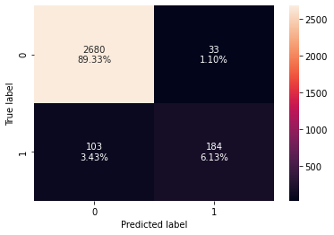

```python
confusion_matrix_sklearn(model, X_train, y_train)
```

```python
decision_tree_perf_test = model_performance_classification_sklearn(
    model, X_test, y_test
)
decision_tree_perf_test
```

|  | Accuracy | Recall | Precision | F1 |
| --- | --- | --- | --- | --- |
| 0 | 0.9475 | 0.601036 | 0.805556 | 0.688427 |

**Observation:** For Logistic Regression we got 94% accuracy for test data. The F1 score is 0.68. Now lets compare that values with other models.

### Building Decision Tree Model

- Decision Trees (DTs) are a non-parametric supervised learning method used for classification and regression. The goal is to create a model that predicts the value of a target variable by learning simple decision rules inferred from the data features.

```python
model = DecisionTreeClassifier(random_state=0, max_depth=8)
model.fit(X_train, y_train)
```

```
DecisionTreeClassifier(max_depth=8, random_state=0)
```

### Checking model performance on training set

```python
decision_tree_perf_train = model_performance_classification_sklearn(
    model, X_train, y_train
)
decision_tree_perf_train
```

|  | Accuracy | Recall | Precision | F1 |
| --- | --- | --- | --- | --- |
| 0 | 0.997667 | 0.979094 | 0.996454 | 0.987698 |

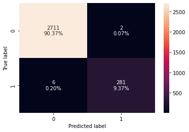

```python
confusion_matrix_sklearn(model, X_train, y_train)
```

### Checking model performance on test set

```python
decision_tree_perf_test = model_performance_classification_sklearn(
    model, X_test, y_test
)
decision_tree_perf_test
```

|  | Accuracy | Recall | Precision | F1 |
| --- | --- | --- | --- | --- |
| 0 | 0.98 | 0.870466 | 0.918033 | 0.893617 |

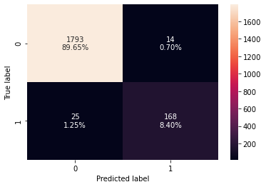

```python
confusion_matrix_sklearn(model, X_test, y_test)
```

**Observation:** Model is giving good and generalized results on training and test set.

### Visualizing the Decision Tree

```python
column_names = list(X.columns)
feature_names = column_names
print(feature_names)
```

```
['Age', 'Experience', 'Income', 'Family', 'CCAvg', 'Education', 'Securities_Account', 'CD_Account', 'Online', 'CreditCard', 'Mortgage_val']
```

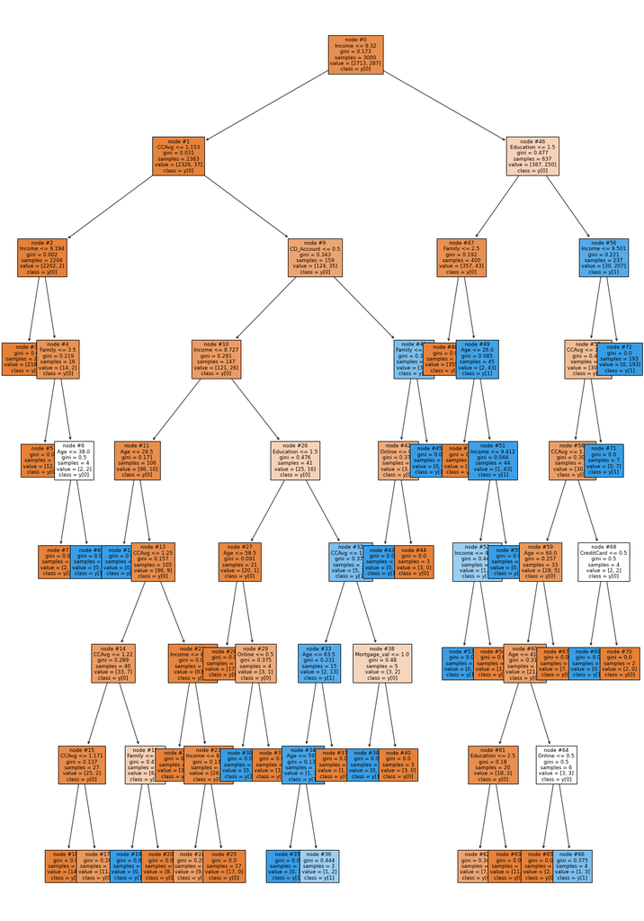

```python
plt.figure(figsize=(20, 30))

out = tree.plot_tree(
    model,
    feature_names=feature_names,
    filled=True,
    fontsize=9,
    node_ids=True,
    class_names=True,
)
for o in out:
    arrow = o.arrow_patch
    if arrow is not None:
        arrow.set_edgecolor("black")
        arrow.set_linewidth(1)
plt.show()
```

```python
# Text report showing the rules of a decision tree -

print(tree.export_text(model, feature_names=feature_names, show_weights=True))
```

```
|--- Income <= 9.32
|   |--- CCAvg <= 1.15
|   |   |--- Income <= 9.19
|   |   |   |--- weights: [2188.00, 0.00] class: 0
|   |   |--- Income >  9.19
|   |   |   |--- Family <= 3.50
|   |   |   |   |--- weights: [12.00, 0.00] class: 0
|   |   |   |--- Family >  3.50
|   |   |   |   |--- Age <= 38.00
|   |   |   |   |   |--- weights: [2.00, 0.00] class: 0
|   |   |   |   |--- Age >  38.00
|   |   |   |   |   |--- weights: [0.00, 2.00] class: 1
|   |--- CCAvg >  1.15
|   |   |--- CD_Account <= 0.50
|   |   |   |--- Income <= 8.73
|   |   |   |   |--- Age <= 26.50
|   |   |   |   |   |--- weights: [0.00, 1.00] class: 1
|   |   |   |   |--- Age >  26.50
|   |   |   |   |   |--- CCAvg <= 1.25
|   |   |   |   |   |   |--- CCAvg <= 1.22
|   |   |   |   |   |   |   |--- CCAvg <= 1.17
|   |   |   |   |   |   |   |   |--- weights: [14.00, 0.00] class: 0
|   |   |   |   |   |   |   |--- CCAvg >  1.17
|   |   |   |   |   |   |   |   |--- weights: [11.00, 2.00] class: 0
|   |   |   |   |   |   |--- CCAvg >  1.22
|   |   |   |   |   |   |   |--- Family <= 3.00
|   |   |   |   |   |   |   |   |--- weights: [0.00, 5.00] class: 1
|   |   |   |   |   |   |   |--- Family >  3.00
|   |   |   |   |   |   |   |   |--- weights: [8.00, 0.00] class: 0
|   |   |   |   |   |--- CCAvg >  1.25
|   |   |   |   |   |   |--- Income <= 8.32
|   |   |   |   |   |   |   |--- weights: [37.00, 0.00] class: 0
|   |   |   |   |   |   |--- Income >  8.32
|   |   |   |   |   |   |   |--- Income <= 8.40
|   |   |   |   |   |   |   |   |--- weights: [9.00, 2.00] class: 0
|   |   |   |   |   |   |   |--- Income >  8.40
|   |   |   |   |   |   |   |   |--- weights: [17.00, 0.00] class: 0
|   |   |   |--- Income >  8.73
|   |   |   |   |--- Education <= 1.50
|   |   |   |   |   |--- Age <= 58.50
```

[output cut: 54 more lines]

```
|   |   |   |   |   |   |   |--- Online <= 0.50
|   |   |   |   |   |   |   |   |--- weights: [2.00, 0.00] class: 0
|   |   |   |   |   |   |   |--- Online >  0.50
|   |   |   |   |   |   |   |   |--- weights: [1.00, 3.00] class: 1
|   |   |   |   |   |--- Age >  60.00
|   |   |   |   |   |   |--- weights: [7.00, 0.00] class: 0
|   |   |   |   |--- CCAvg >  1.13
|   |   |   |   |   |--- CreditCard <= 0.50
|   |   |   |   |   |   |--- weights: [0.00, 2.00] class: 1
|   |   |   |   |   |--- CreditCard >  0.50
|   |   |   |   |   |   |--- weights: [2.00, 0.00] class: 0
|   |   |   |--- CCAvg >  1.24
|   |   |   |   |--- weights: [0.00, 7.00] class: 1
|   |   |--- Income >  9.50
|   |   |   |--- weights: [0.00, 193.00] class: 1
```

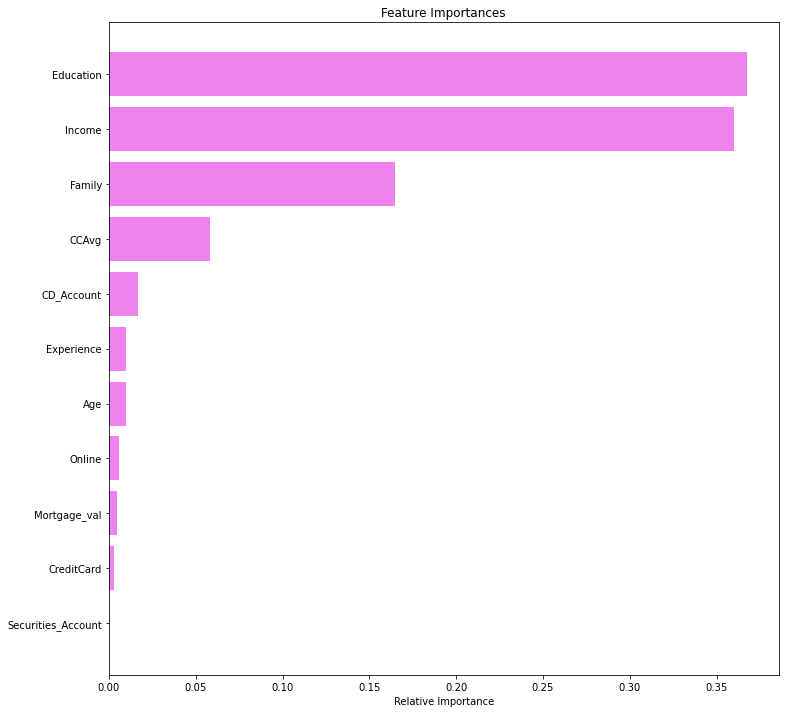

```python
importances = model.feature_importances_
indices = np.argsort(importances)

plt.figure(figsize=(12, 12))
plt.title("Feature Importances")
plt.barh(range(len(indices)), importances[indices], color="violet", align="center")
plt.yticks(range(len(indices)), [feature_names[i] for i in indices])
plt.xlabel("Relative Importance")
plt.show()
```

**Obseravtion:** Education, Income and Family are the top 3 important features.

### Using GridSearch for Hyperparameter tuning of our tree model

- Let's see if we can improve our model performance even more.

```python
# Choose the type of classifier.
estimator = DecisionTreeClassifier(random_state=1)

# Grid of parameters to choose from

parameters = {
    "max_depth": [np.arange(2, 50, 5), None],
    "criterion": ["entropy", "gini"],
    "splitter": ["best", "random"],
    "min_impurity_decrease": [0.000001, 0.00001, 0.0001],
}

# Type of scoring used to compare parameter combinations
acc_scorer = make_scorer(recall_score)

# Run the grid search
grid_obj = GridSearchCV(estimator, parameters, scoring=acc_scorer, cv=5)
grid_obj = grid_obj.fit(X_train, y_train)

# Set the clf to the best combination of parameters
estimator = grid_obj.best_estimator_

# Fit the best algorithm to the data.
estimator.fit(X_train, y_train)
```

```
DecisionTreeClassifier(min_impurity_decrease=1e-06, random_state=1)
```

### Checking performance on training set

```python
decision_tree_tune_perf_train = model_performance_classification_sklearn(
    estimator, X_train, y_train
)
decision_tree_tune_perf_train
```

|  | Accuracy | Recall | Precision | F1 |
| --- | --- | --- | --- | --- |
| 0 | 1.0 | 1.0 | 1.0 | 1.0 |

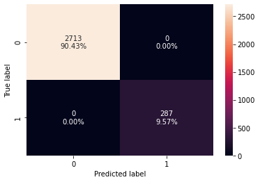

```python
confusion_matrix_sklearn(estimator, X_train, y_train)
```

```python
decision_tree_tune_perf_test = model_performance_classification_sklearn(
    estimator, X_test, y_test
)

decision_tree_tune_perf_test
```

|  | Accuracy | Recall | Precision | F1 |
| --- | --- | --- | --- | --- |
| 0 | 0.9795 | 0.860104 | 0.922222 | 0.89008 |

[figure not shown]

```python
confusion_matrix_sklearn(estimator, X_test, y_test)
```

**Observation:**

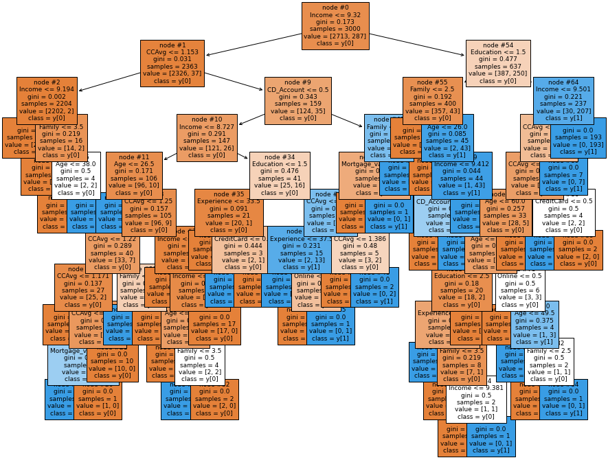

```python
plt.figure(figsize=(15, 12))

tree.plot_tree(
    estimator,
    feature_names=feature_names,
    filled=True,
    fontsize=9,
    node_ids=True,
    class_names=True,
)
plt.show()
```

**Observation:**

### Cost Complexity Pruning

```python
clf = DecisionTreeClassifier(random_state=1)
path = clf.cost_complexity_pruning_path(X_train, y_train)
ccp_alphas, impurities = path.ccp_alphas, path.impurities
```

```python
pd.DataFrame(path)
```

|  | ccp_alphas | impurities |
| --- | --- | --- |
| 0 | 0.000000 | 0.000000 |
| 1 | 0.000250 | 0.000500 |
| 2 | 0.000292 | 0.001083 |
| 3 | 0.000308 | 0.001700 |
| 4 | 0.000310 | 0.002319 |
| 5 | 0.000317 | 0.002954 |
| 6 | 0.000323 | 0.004246 |
| 7 | 0.000326 | 0.004898 |
| 8 | 0.000376 | 0.006026 |
| 9 | 0.000412 | 0.007261 |
| 10 | 0.000444 | 0.008593 |
| 11 | 0.000478 | 0.009548 |
| 12 | 0.000500 | 0.010048 |
| 13 | 0.000537 | 0.010585 |
| 14 | 0.000623 | 0.011207 |
| 15 | 0.000672 | 0.012552 |
| 16 | 0.000878 | 0.016063 |
| 17 | 0.001000 | 0.017063 |
| 18 | 0.002508 | 0.024587 |
| 19 | 0.002580 | 0.027167 |
| 20 | 0.004751 | 0.031918 |
| 21 | 0.011105 | 0.043023 |
| 22 | 0.024311 | 0.067334 |
| 23 | 0.052848 | 0.173029 |

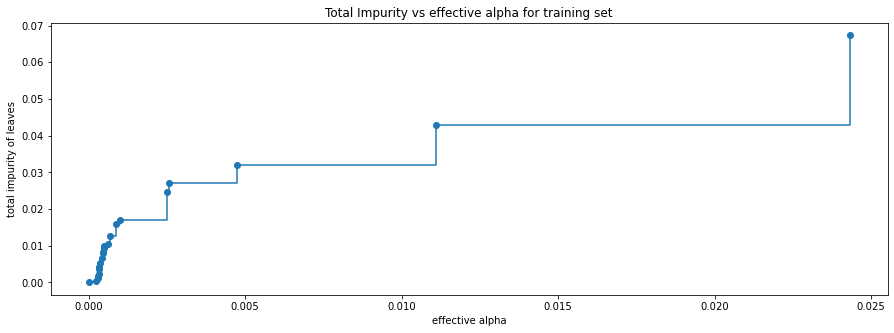

```python
fig, ax = plt.subplots(figsize=(15, 5))
ax.plot(ccp_alphas[:-1], impurities[:-1], marker="o", drawstyle="steps-post")
ax.set_xlabel("effective alpha")
ax.set_ylabel("total impurity of leaves")
ax.set_title("Total Impurity vs effective alpha for training set")
plt.show()
```

```python
clfs = []
for ccp_alpha in ccp_alphas:
    clf = DecisionTreeClassifier(random_state=1, ccp_alpha=ccp_alpha)
    clf.fit(X_train, y_train)
    clfs.append(clf)
print(
    "Number of nodes in the last tree is: {} with ccp_alpha: {}".format(
        clfs[-1].tree_.node_count, ccp_alphas[-1]
    )
)
```

```
Number of nodes in the last tree is: 1 with ccp_alpha: 0.05284766110239135
```

- For the remainder, we remove the last element in clfs and ccp_alphas, because it is the trivial tree with only one node. Here we show that the number of nodes and tree depth decreases as alpha increases.

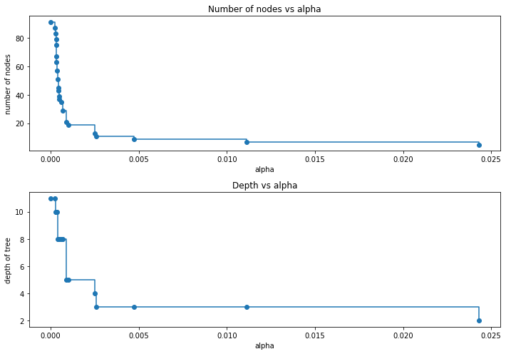

```python
clfs = clfs[:-1]
ccp_alphas = ccp_alphas[:-1]

node_counts = [clf.tree_.node_count for clf in clfs]
depth = [clf.tree_.max_depth for clf in clfs]
fig, ax = plt.subplots(2, 1, figsize=(10, 7))
ax[0].plot(ccp_alphas, node_counts, marker="o", drawstyle="steps-post")
ax[0].set_xlabel("alpha")
ax[0].set_ylabel("number of nodes")
ax[0].set_title("Number of nodes vs alpha")
ax[1].plot(ccp_alphas, depth, marker="o", drawstyle="steps-post")
ax[1].set_xlabel("alpha")
ax[1].set_ylabel("depth of tree")
ax[1].set_title("Depth vs alpha")
fig.tight_layout()
```

### Recall vs alpha for training and testing sets

```python
recall_train = []
for clf in clfs:
    pred_train = clf.predict(X_train)
    values_train = recall_score(y_train, pred_train)
    recall_train.append(values_train)
```

```python
recall_test = []
for clf in clfs:
    pred_test = clf.predict(X_test)
    values_test = recall_score(y_test, pred_test)
    recall_test.append(values_test)
```

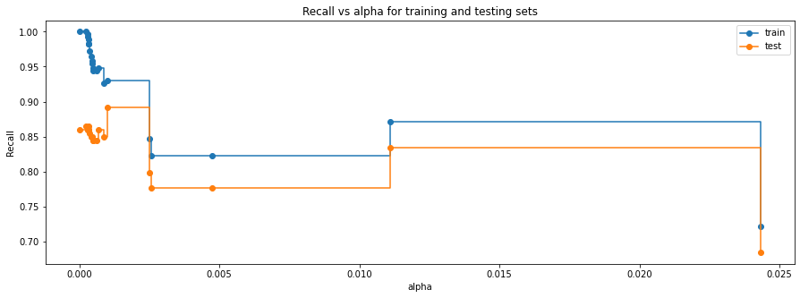

```python
fig, ax = plt.subplots(figsize=(15, 5))
ax.set_xlabel("alpha")
ax.set_ylabel("Recall")
ax.set_title("Recall vs alpha for training and testing sets")
ax.plot(ccp_alphas, recall_train, marker="o", label="train", drawstyle="steps-post")
ax.plot(ccp_alphas, recall_test, marker="o", label="test", drawstyle="steps-post")
ax.legend()
plt.show()
```

```python
# creating the model where we get highest train and test recall
index_best_model = np.argmax(recall_test)
best_model = clfs[index_best_model]
print(best_model)
```

```
DecisionTreeClassifier(ccp_alpha=0.001, random_state=1)
```

### Checking model performance on training set

```python
decision_tree_postpruned_perf_train = model_performance_classification_sklearn(
    best_model, X_train, y_train
)
decision_tree_postpruned_perf_train
```

|  | Accuracy | Recall | Precision | F1 |
| --- | --- | --- | --- | --- |
| 0 | 0.99 | 0.930314 | 0.963899 | 0.946809 |

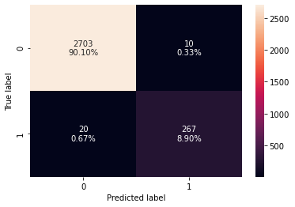

```python
confusion_matrix_sklearn(best_model, X_train, y_train)
```

```python
decision_tree_postpruned_perf_test = model_performance_classification_sklearn(
    best_model, X_test, y_test
)
decision_tree_postpruned_perf_test
```

|  | Accuracy | Recall | Precision | F1 |
| --- | --- | --- | --- | --- |
| 0 | 0.9825 | 0.891192 | 0.924731 | 0.907652 |

- With post-pruning we are getting good and generalized model performance on both training and test set.
- The recall has improved further.

### Visualizing the Decision Tree

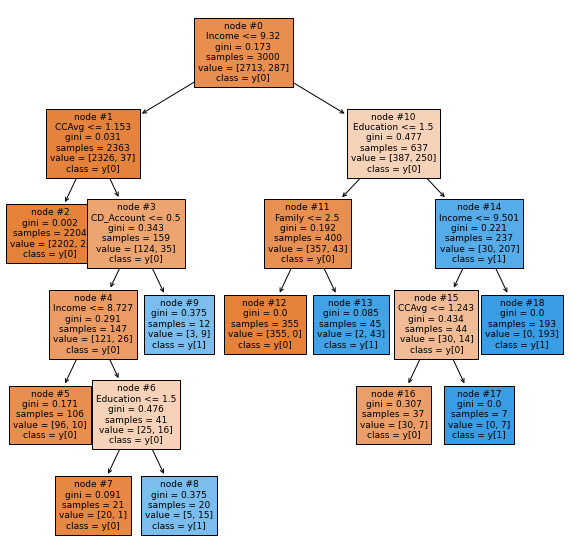

```python
plt.figure(figsize=(10, 10))

out = tree.plot_tree(
    best_model,
    feature_names=feature_names,
    filled=True,
    fontsize=9,
    node_ids=True,
    class_names=True,
)
for o in out:
    arrow = o.arrow_patch
    if arrow is not None:
        arrow.set_edgecolor("black")
        arrow.set_linewidth(1)
plt.show()
plt.show()
```

```python
# Text report showing the rules of a decision tree -

print(tree.export_text(best_model, feature_names=feature_names, show_weights=True))
```

```
|--- Income <= 9.32
|   |--- CCAvg <= 1.15
|   |   |--- weights: [2202.00, 2.00] class: 0
|   |--- CCAvg >  1.15
|   |   |--- CD_Account <= 0.50
|   |   |   |--- Income <= 8.73
|   |   |   |   |--- weights: [96.00, 10.00] class: 0
|   |   |   |--- Income >  8.73
|   |   |   |   |--- Education <= 1.50
|   |   |   |   |   |--- weights: [20.00, 1.00] class: 0
|   |   |   |   |--- Education >  1.50
|   |   |   |   |   |--- weights: [5.00, 15.00] class: 1
|   |   |--- CD_Account >  0.50
|   |   |   |--- weights: [3.00, 9.00] class: 1
|--- Income >  9.32
|   |--- Education <= 1.50
|   |   |--- Family <= 2.50
|   |   |   |--- weights: [355.00, 0.00] class: 0
|   |   |--- Family >  2.50
|   |   |   |--- weights: [2.00, 43.00] class: 1
|   |--- Education >  1.50
|   |   |--- Income <= 9.50
|   |   |   |--- CCAvg <= 1.24
|   |   |   |   |--- weights: [30.00, 7.00] class: 0
|   |   |   |--- CCAvg >  1.24
|   |   |   |   |--- weights: [0.00, 7.00] class: 1
|   |   |--- Income >  9.50
|   |   |   |--- weights: [0.00, 193.00] class: 1
```

```python
# importance of features in the tree building ( The importance of a feature is computed as the
# (normalized) total reduction of the 'criterion' brought by that feature. It is also known as the Gini importance )

print(
    pd.DataFrame(
        best_model.feature_importances_, columns=["Imp"], index=X_train.columns
    ).sort_values(by="Imp", ascending=False)
)
```

```
                         Imp
Education           0.394775
Income              0.386771
Family              0.155873
CCAvg               0.047004
CD_Account          0.015577
Age                 0.000000
Securities_Account  0.000000
Online              0.000000
CreditCard          0.000000
Mortgage_val        0.000000
```

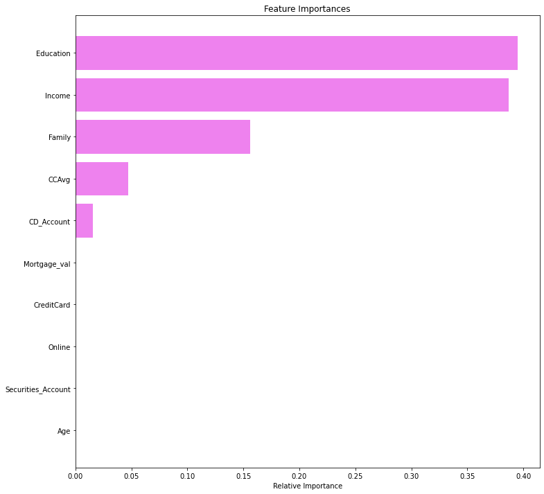

```python
importances = best_model.feature_importances_
indices = np.argsort(importances)

plt.figure(figsize=(12, 12))
plt.title("Feature Importances")
plt.barh(range(len(indices)), importances[indices], color="violet", align="center")
plt.yticks(range(len(indices)), [feature_names[i] for i in indices])
plt.xlabel("Relative Importance")
plt.show()
```

- Education, Income, Family and CCAvg remain the most important feature with post-pruning too.

### Comparing all the decision tree models

```python
# training performance comparison

models_train_comp_df = pd.concat(
    [
        decision_tree_perf_train.T,
        decision_tree_tune_perf_train.T,
        decision_tree_postpruned_perf_train.T,
    ],
    axis=1,
)
models_train_comp_df.columns = [
    "Decision Tree sklearn",
    "Decision Tree (Pre-Pruning)",
    "Decision Tree (Post-Pruning)",
]
print("Training performance comparison:")
models_train_comp_df
```

```
Training performance comparison:
```

|  | Decision Tree sklearn | Decision Tree (Pre-Pruning) | Decision Tree (Post-Pruning) |
| --- | --- | --- | --- |
| Accuracy | 0.997667 | 1.0 | 0.990000 |
| Recall | 0.979094 | 1.0 | 0.930314 |
| Precision | 0.996454 | 1.0 | 0.963899 |
| F1 | 0.987698 | 1.0 | 0.946809 |

```python
# test performance comparison

models_train_comp_df = pd.concat(
    [
        decision_tree_perf_test.T,
        decision_tree_tune_perf_test.T,
        decision_tree_postpruned_perf_test.T,
    ],
    axis=1,
)
models_train_comp_df.columns = [
    "Decision Tree sklearn",
    "Decision Tree (Pre-Pruning)",
    "Decision Tree (Post-Pruning)",
]
print("Test set performance comparison:")
models_train_comp_df
```

```
Test set performance comparison:
```

|  | Decision Tree sklearn | Decision Tree (Pre-Pruning) | Decision Tree (Post-Pruning) |
| --- | --- | --- | --- |
| Accuracy | 0.980000 | 0.979500 | 0.982500 |
| Recall | 0.870466 | 0.860104 | 0.891192 |
| Precision | 0.918033 | 0.922222 | 0.924731 |
| F1 | 0.893617 | 0.890080 | 0.907652 |

- Decision tree with post-pruning is giving the highest recall on the test set.